# Correlation analysis Krill recriutment and environmental covariables

Stock assessment krill populations supplementary methods

Mardones, M; Rebolledo, L. ; Krugger, L.

28 July, 2023

```r
rm(list = ls())
knitr::opts_chunk$set(echo = TRUE,
                      message = FALSE,
                      warning = FALSE,
                      fig.align = 'center',
                      dev = 'jpeg',
                      dpi = 300)
#XQuartz is a mess, put this in your onload to default to cairo instead
options(bitmapType = "cairo")
# (https://github.com/tidyverse/ggplot2/issues/2655)
# Lo mapas se hacen mas rapido
```

```r
library(reshape2)
library(tidyverse)
library(plyr)
library(lubridate)
library(raster)
library(sf)
library(CCAMLRGIS)
library(here)
library(easystats)
library(see) # for plotting
library(ggraph) # needs to be loaded# analisis estadisticos post
library(ggridges)
library(ggpubr)
library(knitr)
library(kableExtra)
# stat test
library(corrplot)
library(outliers)
library(visreg)
# correlation test
library(PerformanceAnalytics)
library(psych)
library(lme4)
library(sjPlot)
library(ggthemes)
```

```r
My_theme <- theme(axis.text.y = element_blank(),
                  axis.ticks.y = element_blank(),
                  axis.ticks.x=element_blank(),
                  panel.background = element_blank(),
                  panel.border = element_rect(fill = NA,
                                              size = 1),
                  strip.background = element_rect(fill = "white",
                                                  color = "white",
                                                  size = 1),
                  text = element_text(size = 14),
                  panel.grid.major = element_line(colour = "white",
                                                  size = 0.1),
                  panel.grid.minor = element_line(colour = "white",
                                                  size = 0.1))
```

# Background

The following document intends to carry out a complementary methodological analysis to correlate environmental variables with the population dynamics of krill (*Euphausia superba*), in this case, with a biological component like lengths from fishery monitoring.

The main idea is join length and covariabes into strata polygons.

# Packages used

Schlegel & Smit (2018), Chamberlain (2023)

# Secuencia analysis

- Cargar shapefiles de los stratas
- Cargar datos Ambientales `dataenvf`
- Cargar datos de de longitud krill `sf4`

```r
#load("datgeo5.RData")
#load("datchl.RData")
#load("dattsm.RData")
#load("~/DOCAS/Data/KrillLows/DataEnvKrill.RData")
BioKrill <- readRDS("BioKrill.Rdata")
```

```r
biokrill2 <- BioKrill %>%
  dplyr::select(7, 8, 9, 17, 18, 20, 29, 31, 32) %>%
  filter(asd_code=="481")

dim(biokrill2)
```

```
## [1] 1099040       9
```

change lat-long format to `sf`.

```r
#Transformo
krillgeo <- st_as_sf(biokrill2, coords = c("longitude_haul_start", "latitude_haul_start"),
                  crs = "+proj=latlong +ellps=WGS84")
```

uso las strata compartidas

```r
stratasub <- st_read("Clipped_Strata.shp", quiet=T)
stratasub <- st_transform(stratasub, "+proj=latlong +ellps=WGS84")
```

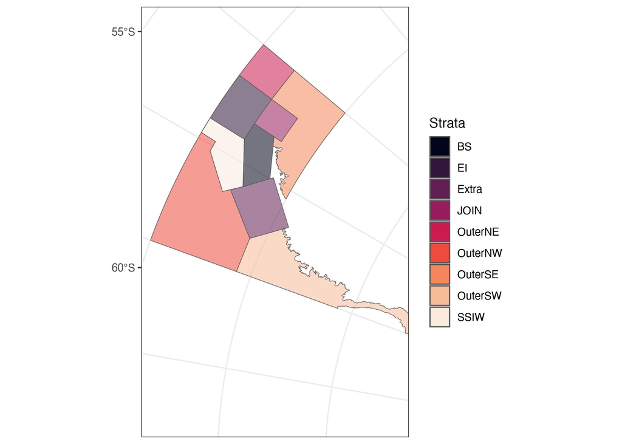

```r
# y testeo el mapa
ssmap <- ggplot()+
  geom_sf(data = stratasub, aes(fill=stratasub$ID,
                           alpha=0.3))+
  scale_fill_viridis_d(option = "F",
                       name="Strata")+
  #geom_sf_label(aes(label = strata$ID))+
  # labs(fill = "SSMU")+
  ylim(230000, 2220000)+
  xlim(-3095349 , -1858911)+
  # coord_sf(crs = 32610)+ #sistema de prpyecccion para campos completos
  coord_sf(crs = 6932)+
  scale_alpha(guide="none")+
  theme_bw()
ssmap
```

Junto las bases con los nuevos estratas. Esto tarda un poco, dado que es dato por dato en el caso de la data de krill lenght.

```r
# comoprobar si tengo datos duplicados
stratasub1 <- st_make_valid(stratasub)
krillgeo1 <- st_make_valid(krillgeo)
krill.strata <- st_join(stratasub1, krillgeo1)
#saveRDS(krill.strata, "KrillData.Rdata")
```

```r
krill.strata<-readRDS("KrillData.Rdata")
```